## Assignment 10

### Preliminaries

- Directories
  - COURSE/homework/
  - COURSE/homework/hw10/
  - COURSE/data/
  - COURSE/scripts/
- Files
  - COURSE/homework/hw10/hw10.Rmd
  - COURSE/data/boston-marathon-data.csv
  - COURSE/data/madison-weather-official-1869-2023.csv
  - COURSE/scripts/viridis.R
  - COURSE/scripts/ggprob.R

### Data

- Some problems use the official Madison weather data, `madison-weather-official-1869-2023.csv`.
- Additional problems use the Boston Marathon data in the file `boston-marathon-data.csv`. This file is a transformed version of the raw data we used in class and has data for all runners who completed the race in 2010 and 2011. The variable `Time` is the sum of the times from the different portions of the race, each of which begins with “K”.

### Aims

- Practice inference on means

## Problems

#### 1

Read in the official Madison weather data. Treat the high temperatures on the dates from April 14 from the twenty year period (2001–2020) as a random sample from a population of potential maximum temperatures in Madison under recent climate conditions at this time of the year. Let $\mu$ and $\sigma$ represent the unknown mean and standard deviations of this population of high temperatures.

-1a. Calculate and display the summary statistics $n$, $\bar{x}$, and $s$, the sample standard deviation.

```r
weather_data = read.csv("../../data/madison-weather-official-1869-2023.csv")
weather_data = weather_data %>%
  mutate(year = year(date)) %>%
  filter(year>2000 & year<2021) %>%
  mutate(month = month(date)) %>%
  filter(month == 4) %>%
  mutate(day = day(date)) %>%
  filter(day == 14)

weather_data2 = weather_data %>%
  summarize(averageTempMax = mean(tmax), sdTempMax = sd(tmax), n = n())

weather_data2
```

```
##   averageTempMax sdTempMax  n
## 1          60.65  15.32207 20
```

-1b. Create a graph to display the distribution of this data. Choose which type of graph is effective for this purpose.

```r
vector = weather_data["tmax"]

weather_data %>%
  summarize(n = n(),
            min = min(tmax),
            q10 = quantile(tmax, 0.10),
            q25 = quantile(tmax, 0.25),
            median = median(tmax),
            q75 = quantile(tmax, 0.75),
            q90 = quantile(tmax, 0.90)) %>%
  print(n = Inf)
```

[output not shown]

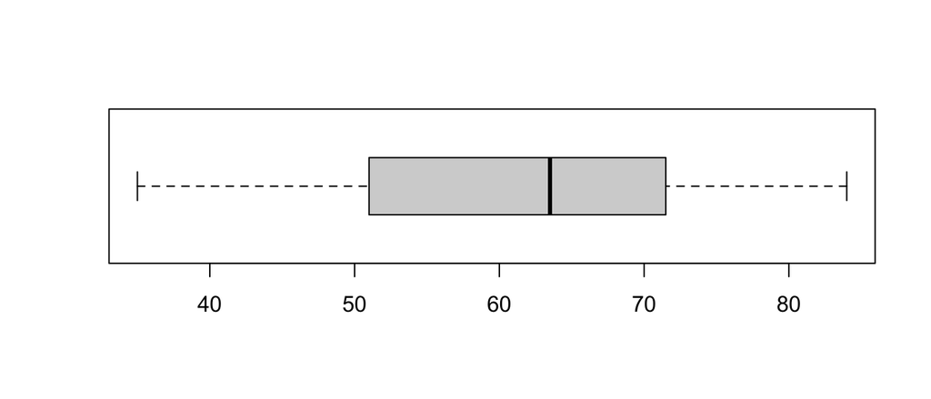

```r
boxplot(vector, horizontal = TRUE)
```

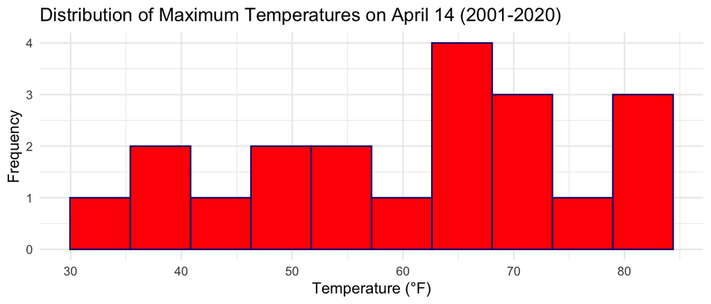

```r
ggplot(weather_data, aes(x = tmax)) +
  geom_histogram(bins = 10,
                 fill = "red",
                 color = "navy") +
  labs(title = "Distribution of Maximum Temperatures on April 14 (2001-2020)",
       x = "Temperature (°F)",
       y = "Frequency")
```

-1c. Describe the distribution of daily maximum temperatures as shown by the graph. Is the distribution strongly skewed? Are there unusual measurements?

> The mean 60.65 is on the left from the median 63.5 which means the data has left skewed distribution.